# Practical Machine Learning (Prediction) - Assignment

Nhlakanipho

21 December 2017

# Synopsis

This paper aims at analyzing the training patterns for 6 diffent users doing Weight Lifting execises. The data set used in this paper was collected by Groupware@LES for their project in Human Activity Recognition which can be found, http://groupware.les.inf.puc-rio.br/har. After exploring, cleaning and applying prediction models on this dataset, the results produced the most likely prediction given specific datapoints.

# Data

Data load from Groupware’s project dataset as our source data. There is a Training set and a Testing set which we will use for our final predictions.

```r
  if(!file.exists("exerciseTrainingData.csv"))
  {
    download.file(
       "https://d396qusza40orc.cloudfront.net/predmachlearn/pml-training.csv"
       ,destfile="./exerciseTrainingData.csv"
       ,method="auto"
    )
  }

  if(!file.exists("exerciseTestData.csv"))
  {
    download.file(
      "https://d396qusza40orc.cloudfront.net/predmachlearn/pml-testing.csv"
      ,destfile="./exerciseTestData.csv"
      ,method="auto"
    )
  }

  exerciseTrainingData <- read.csv(file = "./exerciseTrainingData.csv", sep = ",", header = TRUE, na.strings = c("NA","#DIV/0!"," "))

  exerciseTestData <- read.csv(file = "./exerciseTestData.csv", sep = ",", header = TRUE, na.strings = c("NA","#DIV/0!"," "))
```

In preparation of the data, the Trainng had to be further split to a training set and a validation set which we will use to try verify which model/prediction works better for preditions. A 70% split was used on the training data to get these sets.

```r
library(caret)
set.seed(1654)
inTrain <- createDataPartition(y=exerciseTrainingData$classe,p=0.70, list = FALSE)

myTrainData <- exerciseTrainingData[inTrain,]
myTestData <- exerciseTrainingData[-inTrain,]
```

# Data Exploration and Cleaning

In exploration of the data there was a view on some columns having NA (Index - Diagram1) and some having a very low variance to be considered as they didn’t change much and had a potential of misrepresenting the predictions. Looking at the first 6 values of the data, one can identify all descriptive columns that don’t influence or models but just identify the users.

```r
#head(myTrainData)
#summary(myTrainData)


myTrainDataDescriptive <- myTrainData[,-(1:5)]
myTestDataDescriptive <- myTestData[,-(1:5)]

myTrainDataDescriptive$new_window <- sapply(myTrainDataDescriptive$new_window, function(x){if(x=='no'){x=0}else{x=1}})
myTestDataDescriptive$new_window <- sapply(myTestDataDescriptive$new_window, function(x){if(x=='no'){x=0}else{x=1}})


dim(myTrainDataDescriptive)
```

```
## [1] 13737   155
```

```r
nzvTraining <- nearZeroVar(myTrainDataDescriptive[,-155])
myTrainDataDescriptive <- myTrainDataDescriptive[,-nzvTraining]
myTestDataDescriptive <- myTestDataDescriptive[,-nzvTraining]

rowcount <- nrow(myTrainDataDescriptive)
lenghtDescription <- length(myTrainDataDescriptive)
naData <- colMeans(is.na(myTrainDataDescriptive))

exData <- c()
for(i in 1:lenghtDescription)
{
  if(naData[i] >= .7)
  {
    exData <- append(exData, i)
  }
}

myTrainDataDescriptive <- myTrainDataDescriptive[,-exData]
myTestDataDescriptive <- myTestDataDescriptive[,-exData]

rm(rowcount,lenghtDescription,naData,exData)
```

# Predictions

This section applied model fits and runs predictions on the validation sets to try get the most closely aligned preditions.The models of choice used for identifying the model with the best out of sample error accuracy are Classification Trees, Random Forest and Grdient Boosting Model. Thses are investigated below.

## Classication Tree

In the first test, a classification tree in the form of a regression tree is investigated. By default Rpart using a 10 fold cross validation.

```r
set.seed(4154)
rpartModelFit <- rpart(classe~., data = myTrainDataDescriptive, method = "class")
rpartPredict <- predict(rpartModelFit, myTestDataDescriptive, type = "class")
rpartConf <- confusionMatrix(rpartPredict, myTestDataDescriptive$classe)
```

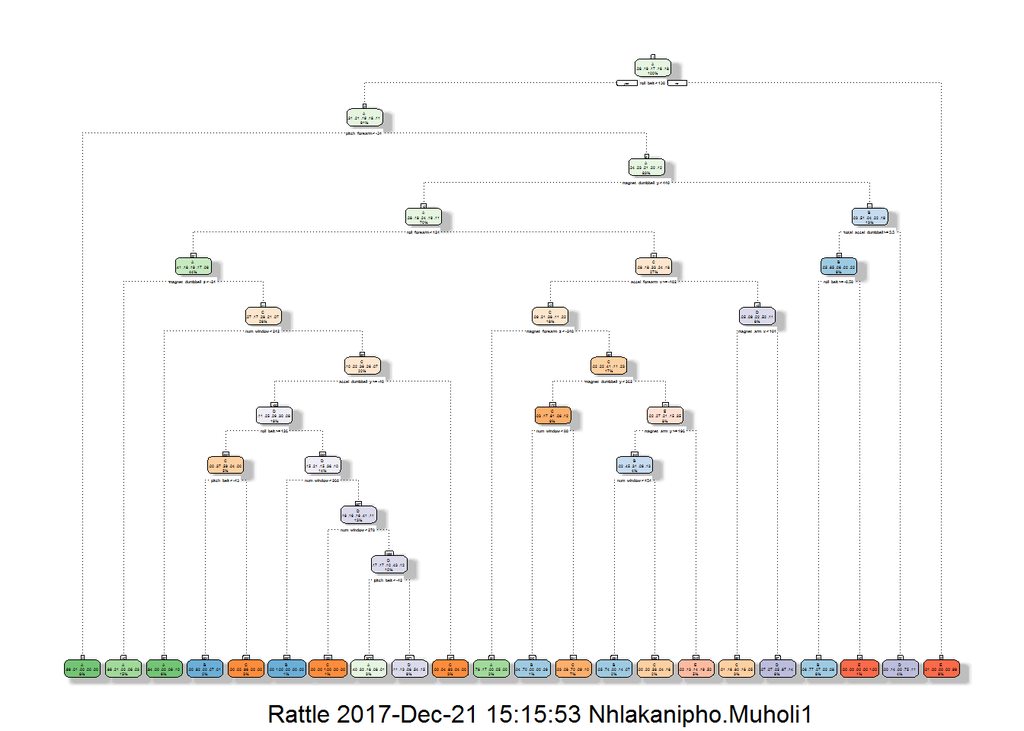

```
## Confusion Matrix and Statistics
##
##           Reference
## Prediction    A    B    C    D    E
##          A 1521  268   49  131   77
##          B   29  580   31   31   80
##          C   16  109  826   82   67
##          D   98  138   85  673  154
##          E   10   44   35   47  704
##
## Overall Statistics
##
##                Accuracy : 0.7314
##                  95% CI : (0.7198, 0.7426)
##     No Information Rate : 0.2845
##     P-Value [Acc > NIR] : < 2.2e-16
##
##                   Kappa : 0.658
##  Mcnemar's Test P-Value : < 2.2e-16
##
## Statistics by Class:
##
##                      Class: A Class: B Class: C Class: D Class: E
## Sensitivity            0.9086  0.50922   0.8051   0.6981   0.6506
## Specificity            0.8753  0.96397   0.9436   0.9035   0.9717
## Pos Pred Value         0.7434  0.77230   0.7509   0.5862   0.8381
## Neg Pred Value         0.9601  0.89112   0.9582   0.9386   0.9251
## Prevalence             0.2845  0.19354   0.1743   0.1638   0.1839
## Detection Rate         0.2585  0.09856   0.1404   0.1144   0.1196
## Detection Prevalence   0.3477  0.12761   0.1869   0.1951   0.1427
## Balanced Accuracy      0.8920  0.73659   0.8743   0.8008   0.8112
```

```
##
## Classification tree:
## rpart(formula = classe ~ ., data = myTrainDataDescriptive, method = "class")
##
## Variables actually used in tree construction:
##  [1] accel_dumbbell_y     accel_forearm_x      magnet_arm_x
##  [4] magnet_arm_y         magnet_dumbbell_y    magnet_dumbbell_z
##  [7] magnet_forearm_z     num_window           pitch_belt
## [10] pitch_forearm        roll_belt            roll_forearm
## [13] total_accel_dumbbell
##
## Root node error: 9831/13737 = 0.71566
##
## n= 13737
##
##          CP nsplit rel error  xerror      xstd
## 1  0.118198      0   1.00000 1.00000 0.0053780
## 2  0.060184      1   0.88180 0.88180 0.0057525
## 3  0.039670      4   0.70125 0.70156 0.0059609
## 4  0.034279      6   0.62191 0.62130 0.0059243
## 5  0.031024      7   0.58763 0.59038 0.0058890
## 6  0.022683      8   0.55661 0.56017 0.0058427
## 7  0.020140     11   0.48795 0.48754 0.0056823
## 8  0.016682     12   0.46781 0.47157 0.0056373
## 9  0.015766     13   0.45112 0.45570 0.0055890
## 10 0.015563     14   0.43536 0.45194 0.0055769
## 11 0.014851     15   0.41979 0.44756 0.0055627
## 12 0.012105     16   0.40494 0.42142 0.0054716
## 13 0.011799     17   0.39284 0.40423 0.0054058
## 14 0.011698     18   0.38104 0.39264 0.0053587
## 15 0.010070     20   0.35764 0.37046 0.0052623
## 16 0.010000     21   0.34757 0.36161 0.0052215
```

## Random Forest

```r
library("randomForest")
```

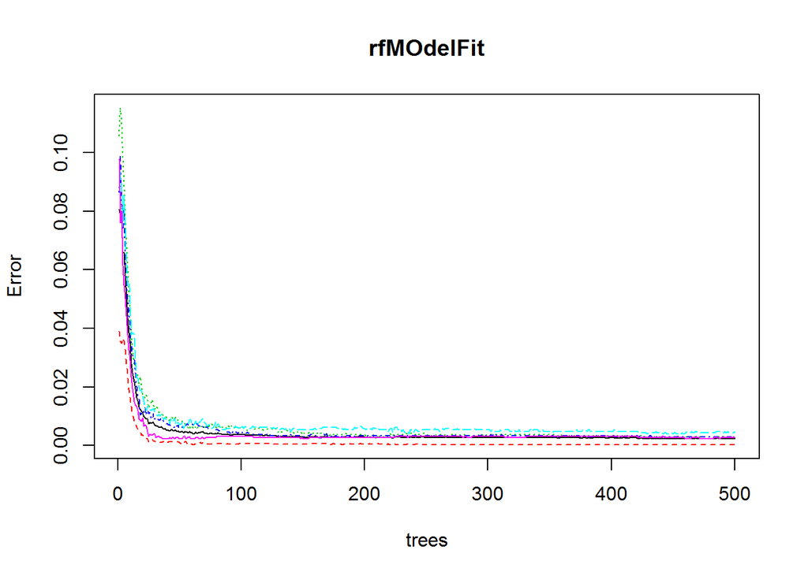

```r
set.seed(3154)
rfMOdelFit <- randomForest(
                            classe~.
                            ,data= myTrainDataDescriptive
                            ,importance = T
                            ,trControl = trainControl(method = "cv", number = 3)
                          )
plot(rfMOdelFit)
```

```r
rfPredict <- predict(rfMOdelFit,myTestDataDescriptive)

rfConf <- confusionMatrix(rfPredict, myTestDataDescriptive$classe)
rfConf
```

```
## Confusion Matrix and Statistics
##
##           Reference
## Prediction    A    B    C    D    E
##          A 1674    6    0    0    0
##          B    0 1133    7    0    0
##          C    0    0 1019    9    0
##          D    0    0    0  955    2
##          E    0    0    0    0 1080
##
## Overall Statistics
##
##                Accuracy : 0.9959
##                  95% CI : (0.9939, 0.9974)
##     No Information Rate : 0.2845
##     P-Value [Acc > NIR] : < 2.2e-16
##
##                   Kappa : 0.9948
##  Mcnemar's Test P-Value : NA
##
## Statistics by Class:
##
##                      Class: A Class: B Class: C Class: D Class: E
## Sensitivity            1.0000   0.9947   0.9932   0.9907   0.9982
## Specificity            0.9986   0.9985   0.9981   0.9996   1.0000
## Pos Pred Value         0.9964   0.9939   0.9912   0.9979   1.0000
## Neg Pred Value         1.0000   0.9987   0.9986   0.9982   0.9996
## Prevalence             0.2845   0.1935   0.1743   0.1638   0.1839
## Detection Rate         0.2845   0.1925   0.1732   0.1623   0.1835
## Detection Prevalence   0.2855   0.1937   0.1747   0.1626   0.1835
## Balanced Accuracy      0.9993   0.9966   0.9957   0.9951   0.9991
```

The results and diagram show how increasing the number of trees decreases the error rate for each classe predition. Random Forest predictions resulted in a 99.6% accuracy rate and a out of sample error rate of 0.4% on the validation dataset.The variable importances for the model is shown in (Index - Diagram3).

## Gradient Boosting Model

Lastly an investiagtion into Gradient Boosting Model is performed to see how it performs in terms of predictions. 3 folds cross validation was used for performance purposes.

```r
set.seed(1154)
gbmModelFit <- train(classe~.,method = 'gbm',data = myTrainDataDescriptive, verbose = FALSE,trControl = trainControl(method = "cv", number = 3))
gbmPredict <- predict(gbmModelFit,myTestDataDescriptive)
```

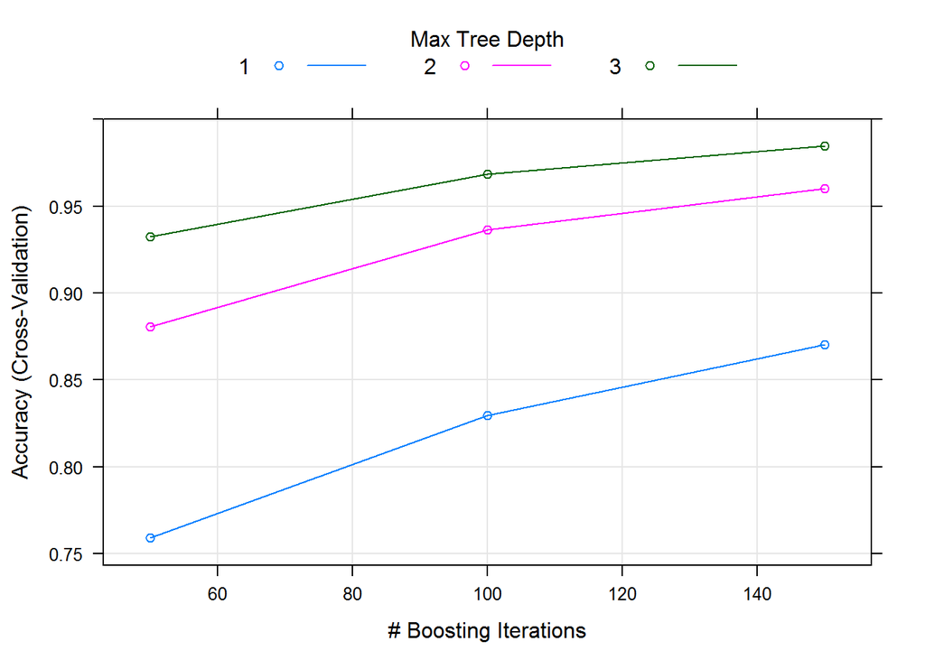

```
## Confusion Matrix and Statistics
##
##           Reference
## Prediction    A    B    C    D    E
##          A 1669   18    0    0    1
##          B    4 1107    6    3    4
##          C    0   13 1017    9    2
##          D    1    1    3  950   11
##          E    0    0    0    2 1064
##
## Overall Statistics
##
##                Accuracy : 0.9867
##                  95% CI : (0.9835, 0.9895)
##     No Information Rate : 0.2845
##     P-Value [Acc > NIR] : < 2.2e-16
##
##                   Kappa : 0.9832
##  Mcnemar's Test P-Value : NA
##
## Statistics by Class:
##
##                      Class: A Class: B Class: C Class: D Class: E
## Sensitivity            0.9970   0.9719   0.9912   0.9855   0.9834
## Specificity            0.9955   0.9964   0.9951   0.9967   0.9996
## Pos Pred Value         0.9887   0.9849   0.9769   0.9834   0.9981
## Neg Pred Value         0.9988   0.9933   0.9981   0.9972   0.9963
## Prevalence             0.2845   0.1935   0.1743   0.1638   0.1839
## Detection Rate         0.2836   0.1881   0.1728   0.1614   0.1808
## Detection Prevalence   0.2868   0.1910   0.1769   0.1641   0.1811
## Balanced Accuracy      0.9963   0.9842   0.9931   0.9911   0.9915
```

The results and diagram show how increasing the number of trees and increasing the boosting increases overall accuracy in preditions. Gradient Boosting Model predictions resulted in a 98.7% accuracy rate and a out of sample error rate of 1.3% on the validation dataset. By default GBM uses the full dataset for predictions under it’s cross validation methods.

# Conclusion

Random Forest Show the highest accuracy and according to accuracy seen for each Confusion Matrix and further check (Index - Diagram 2) which proves there is a high specificy and high sensitivity overall for the Random Forestcompared to the rest of the data.

# Index

## Diagram1

[output not shown]

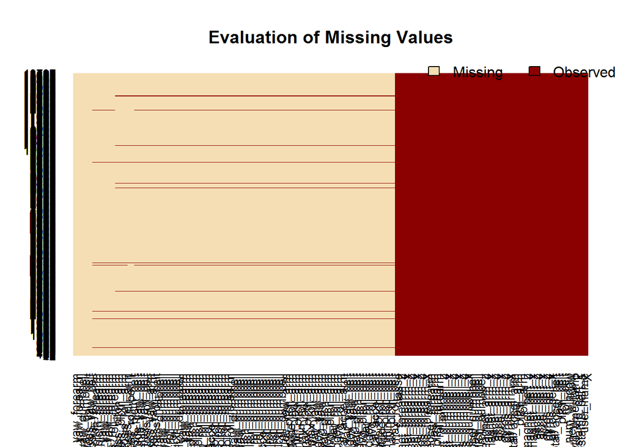

## Diagram2

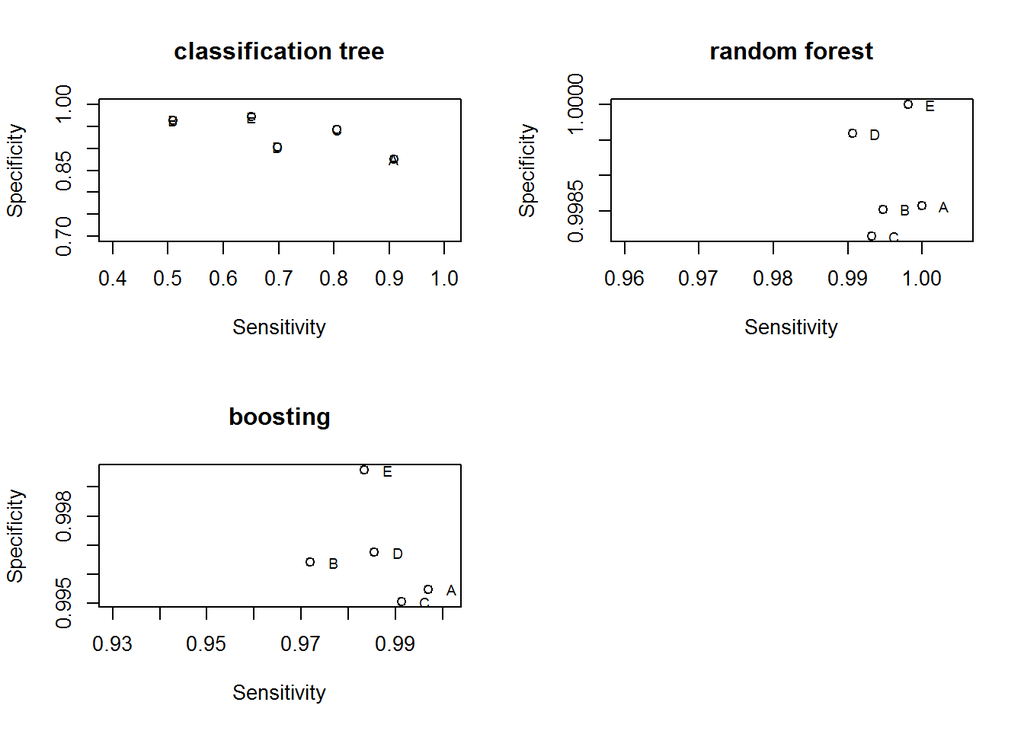

## Diagram3

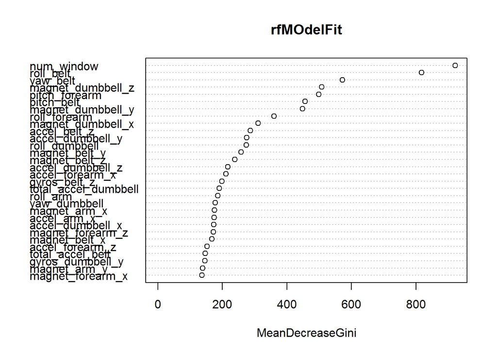